# #Peer Assessment 1

```r
url <- "https://d396qusza40orc.cloudfront.net/repdata%2Fdata%2Factivity.zip"
download.file(url, "Peer Assignment 1", method = "curl")
if(!file.exists("./ReprodResA1")) {dir.create(./ReprodResA1)}
unzip("Peer Assignment 1", exdir = "./ReprodResA1")
stepsData <- read.csv("./ReprodResA1/activity.csv")
```

##Mean number of steps per day

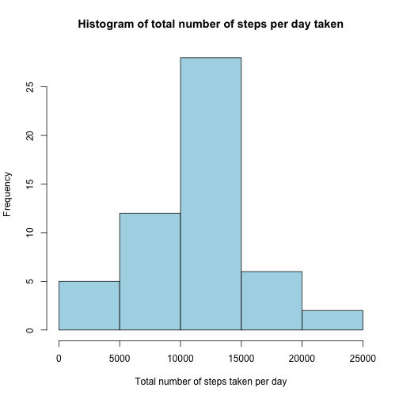

```r
stepsDaily <- tapply(stepsData$steps, INDEX = stepsData$date, sum)
hist(stepsDaily, main = "Histogram of total number of steps per day taken", xlab = "Total number of steps taken per day", col = "light blue")
```

The mean and median of total number of steps taken per day is calculated as follows:

```r
mean(stepsDaily, na.rm = TRUE)
```

```
## [1] 10766
```

```r
median(stepsDaily, na.rm = TRUE)
```

```
## [1] 10765
```

Note that NA values are ignored in the above calculations.

##Average of steps in each interval

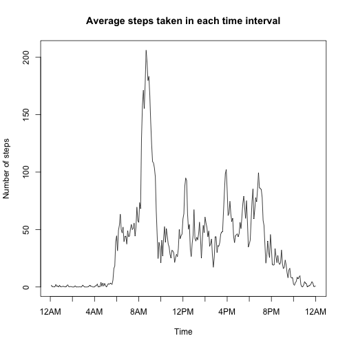

```r
stepsAveItvl <- tapply(stepsData$steps, INDEX = stepsData$interval, mean, na.rm = TRUE)
plot(stepsAveItvl, t ="l", main = "Average steps taken in each time interval", ylab = "Number of steps", xlab = "Time", xaxt = "n")
labels <- c("12AM", "2AM", "4AM", "6AM", "8AM", "10AM", "12PM", "2PM", "4PM", "6PM", "8PM", "10PM", "12AM")
axis(1, at = seq(0, 288, 24), labels = labels)
```

The time interval with the highest average steps taken is identified as follows:

```r
names(which.max(stepsAveItvl))
```

```
## [1] "835"
```

```r
sum(is.na(stepsData$steps))
```

```
## [1] 2304
```

NA values are substituted with mean values of that particular time interval

```r
for (i in 1:nrow(stepsData))
  {
    if(is.na(stepsData[i,1]))
      {
        stepsData[i,1] <- stepsAveItvl[names(stepsAveItvl) == stepsData[i,3]]
      }
  }
```

A snapshot of the processed data:

```
##     steps       date interval
## 1 1.71698 2012-10-01        0
## 2 0.33962 2012-10-01        5
## 3 0.13208 2012-10-01       10
## 4 0.15094 2012-10-01       15
## 5 0.07547 2012-10-01       20
## 6 2.09434 2012-10-01       25
```

With the substitution of NA values:

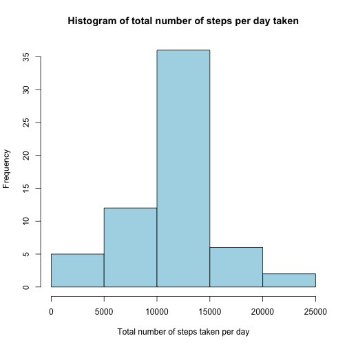

The mean and median of total number of steps taken per day has not changed much as NA values were substituted with average values of the same intervals from other days:

```r
mean(stepsDaily)
```

```
## [1] 10766
```

```r
median(stepsDaily)
```

```
## [1] 10766
```

```r
stepsData$date <- as.Date(stepsData$date)
stepsData$day <- ifelse(weekdays(stepsData$date) %in% c("Saturday", "Sunday"), "weekend", "weekday")
stepsData$day <- factor(stepsData$day)
```

The average steps taken during each interval is calculated for weekdays and weekends.

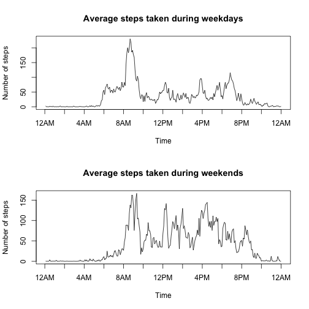

```r
stepsAveItvlWd <- tapply(stepsData[stepsData$day == "weekday", 1], INDEX = stepsData[stepsData$day == "weekday", 3], mean)
stepsAveItvlWe <- tapply(stepsData[stepsData$day == "weekend", 1], INDEX = stepsData[stepsData$day == "weekend", 3], mean)
par(mfrow = c(2,1))
plot(stepsAveItvlWd, t ="l", main = "Average steps taken during weekdays", ylab = "Number of steps", xlab = "Time", xaxt = "n")
labels <- c("12AM", "2AM", "4AM", "6AM", "8AM", "10AM", "12PM", "2PM", "4PM", "6PM", "8PM", "10PM", "12AM")
axis(1, at = seq(0, 288, 24), labels = labels)
plot(stepsAveItvlWe, t ="l", main = "Average steps taken during weekends", ylab = "Number of steps", xlab = "Time", xaxt = "n")
axis(1, at = seq(0, 288, 24), labels = labels)
```